# Finding salmon minimum data for environmetal data pull

The purpose of this code is to figure out the minimum dates of all salmon data for each site, and use this as a reference of the starting date to pull environmental data

### Checking for date ranges

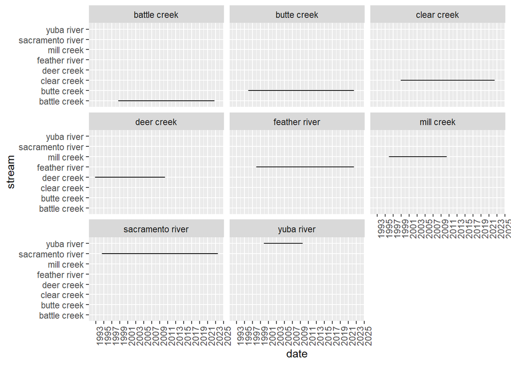

```r
#catch
ggplot(rst_catch, aes(x = date, y = stream)) +
  geom_line() +
  facet_wrap(~stream) +
  scale_x_date(
    date_breaks = "2 years",
    date_labels = "%Y"
  ) +
    theme(axis.text.x = element_text(angle = 90, hjust = 1))
```

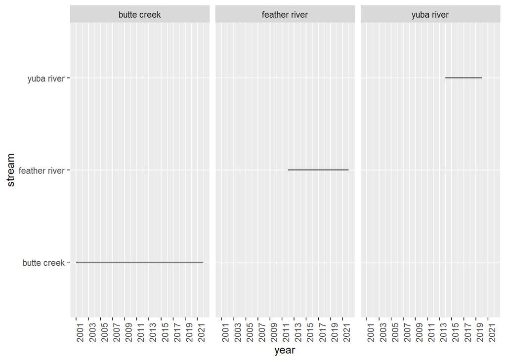

```r
#carcass_estimates
ggplot(carcass_estimates, aes(x = year, y = stream)) +
  geom_line() +
  facet_wrap(~stream) +
      scale_x_continuous(
    breaks = seq(floor(min(carcass_estimates$year, na.rm = TRUE)),
                 ceiling(max(carcass_estimates$year, na.rm = TRUE)),
                 by = 2),
    labels = as.character
  ) +
  theme(axis.text.x = element_text(angle = 90, hjust = 1))
```

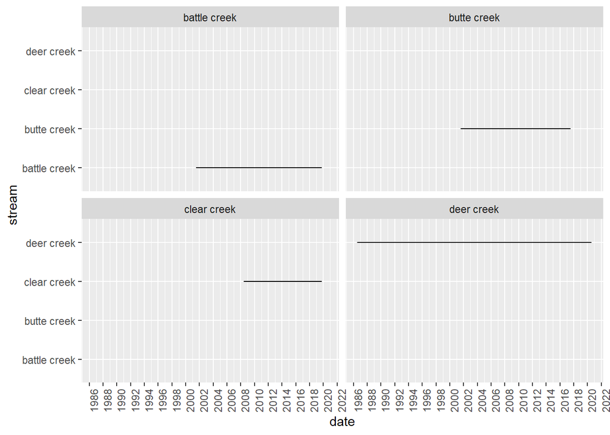

```r
#holding
ggplot(holding, aes(x = date, y = stream)) +
  geom_line() +
  facet_wrap(~stream) +
  scale_x_date(
    date_breaks = "2 years",
    date_labels = "%Y"
  ) +
    theme(axis.text.x = element_text(angle = 90, hjust = 1))
```

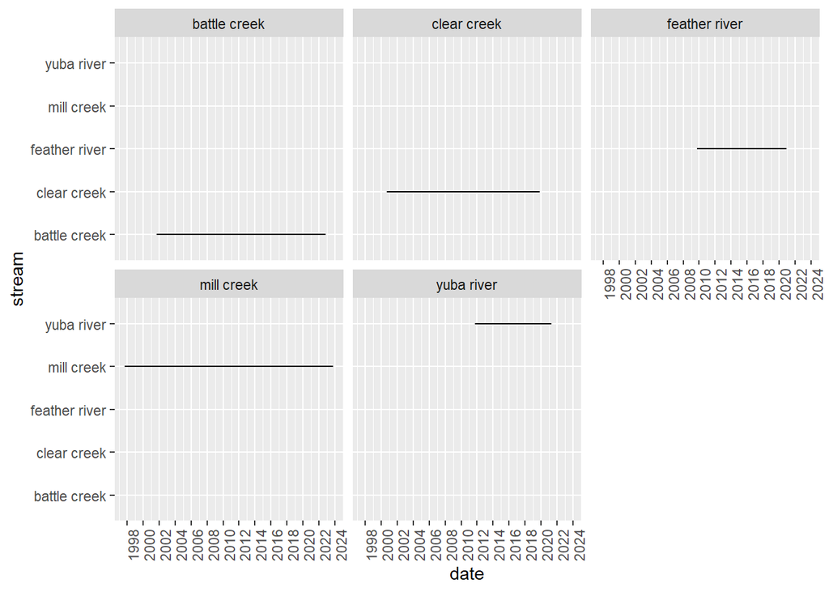

```r
#redd
ggplot(redd, aes(x = date, y = stream)) +
  geom_line() +
  facet_wrap(~stream) +
  scale_x_date(
    date_breaks = "2 years",
    date_labels = "%Y"
  ) +
    theme(axis.text.x = element_text(angle = 90, hjust = 1))
```

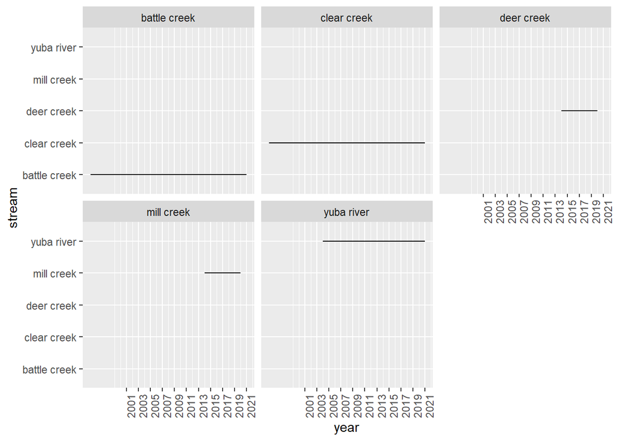

```r
#upstream_passage_estimates
ggplot(upstream_passage_estimates, aes(x = year, y = stream)) +
  geom_line() +
  facet_wrap(~stream) +
      scale_x_continuous(
    breaks = seq(floor(min(carcass_estimates$year, na.rm = TRUE)),
                 ceiling(max(carcass_estimates$year, na.rm = TRUE)),
                 by = 2),
    labels = as.character
  ) +
  theme(axis.text.x = element_text(angle = 90, hjust = 1))
```

Summary of minimum date ranges:

- Battle Creek - 1995
- Butte Creek - 1995
- Clear Creek - 1995
- Deer Creek - 1986
- Feather River - 1997
- Mill Creek - 1995
- Sacramento River - 1994
- Yuba River - 1999

## Battle Creek —

- Earliest year of salmon data available = 1995

*rst_catch*

```r
battle_catch <- rst_catch |>
  filter(stream == "battle creek") |>
  glimpse()
```

```
## Rows: 72,736
## Columns: 14
## $ date            <date> 1999-01-20, 1999-01-20, 1999-01-20, 1999-01-20, 1999-…
## $ stream          <chr> "battle creek", "battle creek", "battle creek", "battl…
## $ site            <chr> "lbc", "lbc", "lbc", "lbc", "lbc", "ubc", "ubc", "lbc"…
## $ subsite         <chr> "lbc", "lbc", "lbc", "lbc", "lbc", "ubc", "ubc", "lbc"…
## $ site_group      <chr> "battle creek", "battle creek", "battle creek", "battl…
## $ count           <dbl> 1, 3, 1, 4, 2, 1, 1, 1, 2, 1, 1, 1, 4, 8, 8, 6, 1, 314…
## $ run             <chr> "fall", "fall", "fall", "fall", "fall", "fall", "fall"…
## $ life_stage      <chr> "fry", "fry", "fry", "fry", "fry", "fry", "fry", "fry"…
## $ adipose_clipped <lgl> FALSE, FALSE, FALSE, FALSE, FALSE, FALSE, FALSE, FALSE…
## $ dead            <lgl> NA, NA, NA, NA, NA, NA, NA, NA, NA, NA, NA, NA, NA, NA…
## $ fork_length     <dbl> 35, 38, 34, 36, 37, 38, 37, 40, 39, 31, 39, 0, 38, 37,…
## $ weight          <dbl> 0, 0, 0, 0, 0, 0, 0, 0, 0, 0, 0, 0, 0, 0, 0, 0, 0, 0, …
## $ actual_count    <lgl> NA, NA, NA, NA, NA, NA, NA, NA, NA, NA, NA, NA, NA, NA…
## $ species         <chr> "chinook", "chinook", "chinook", "chinook", "chinook",…
```

```r
range(battle_catch$date) #"1998-08-31" "2022-09-30"
```

```
## [1] "1998-08-31" "2022-09-30"
```

No battle in *carcass_estimate*

*holding*

```r
battle_holding <- holding |>
  filter(stream == "battle creek") |>
  glimpse()
```

```
## Rows: 1,339
## Columns: 8
## $ date            <date> 2001-07-19, 2001-07-19, 2001-07-19, 2001-07-19, 2001-…
## $ stream          <chr> "battle creek", "battle creek", "battle creek", "battl…
## $ reach           <chr> "R3", "R3", "R3", "R3", "R3", "R4", "R4", "R5", "R3", …
## $ count           <dbl> 4, 1, 3, 4, 5, 2, 1, 1, 3, 1, 5, 3, 4, 1, 3, 6, 3, 5, …
## $ adipose_clipped <lgl> FALSE, FALSE, FALSE, FALSE, FALSE, FALSE, FALSE, FALSE…
## $ run             <chr> "spring", "spring", "spring", "spring", "spring", "spr…
## $ latitude        <dbl> 40.41491, 40.40429, 40.40363, 40.40277, 40.40204, 40.4…
## $ longitude       <dbl> -121.9902, -121.9793, -121.9754, -121.9743, -121.9687,…
```

```r
range(battle_holding$date) #"2001-07-19" "2019-10-18"
```

```
## [1] "2001-07-19" "2019-10-18"
```

*redd*

```r
battle_redd <- redd |>
  filter(stream == "battle creek") |>
  glimpse()
```

```
## Rows: 2,496
## Columns: 9
## $ date      <date> 2002-10-01, 2002-10-01, 2002-10-01, 2002-10-01, 2002-10-01,…
## $ stream    <chr> "battle creek", "battle creek", "battle creek", "battle cree…
## $ reach     <chr> "R2", "R2", "R2", "R2", "R2", "R2", "R3", "R3", "R2", "R2", …
## $ latitude  <dbl> 40, 40, 40, 40, 40, 40, 40, 40, 40, 40, 40, 40, 40, 40, 40, …
## $ longitude <dbl> -122, -122, -122, -122, -122, -122, -122, -122, -122, -122, …
## $ run       <chr> "not recorded", "not recorded", "not recorded", "not recorde…
## $ velocity  <dbl> NA, NA, NA, NA, NA, NA, NA, NA, 2, 2, 2, NA, NA, 1, 1, 3, 3,…
## $ redd_id   <chr> "Redd_0035", "Redd_0036", "Redd_0037", "Redd_0038", "Redd_00…
## $ age       <int> NA, NA, NA, NA, NA, NA, NA, NA, NA, NA, NA, NA, NA, NA, NA, …
```

```r
range(redd$date) # "1997-10-01" "2023-10-01"
```

```
## [1] "1997-10-01" "2023-10-01"
```

*upstream_passage_estimates*

```r
battle_upstream_estimates <- upstream_passage_estimates |>
  filter(stream == "battle creek") |>
  glimpse()
```

```
## Rows: 27
## Columns: 9
## $ year                 <int> 1995, 1996, 1997, 1998, 1999, 2000, 2001, 2002, 2…
## $ stream               <chr> "battle creek", "battle creek", "battle creek", "…
## $ reach                <chr> NA, NA, NA, NA, NA, NA, NA, NA, NA, NA, NA, NA, N…
## $ passage_estimate     <dbl> 66, 35, 107, 178, 73, 78, 111, 222, 221, 90, 73, …
## $ adipose_clipped      <lgl> FALSE, FALSE, FALSE, FALSE, FALSE, FALSE, FALSE, …
## $ run                  <chr> "spring", "spring", "spring", "spring", "spring",…
## $ upper_bound_estimate <int> NA, NA, NA, NA, NA, NA, NA, NA, NA, NA, NA, NA, N…
## $ lower_bound_estimate <int> NA, NA, NA, NA, NA, NA, NA, NA, NA, NA, NA, NA, N…
## $ confidence_level     <dbl> NA, NA, NA, NA, NA, NA, NA, NA, NA, NA, NA, NA, N…
```

```r
range(battle_upstream_estimates$year) #1995 2021
```

```
## [1] 1995 2021
```

### Butte Creek —

- Earliest year of salmon data available = 1995

*rst_catch*

```r
butte_catch <- rst_catch |>
  filter(stream == "butte creek") |>
  glimpse()
```

```
## Rows: 63,762
## Columns: 14
## $ date            <date> 1995-12-01, 1995-12-01, 1995-12-01, 1995-12-01, 1995-…
## $ stream          <chr> "butte creek", "butte creek", "butte creek", "butte cr…
## $ site            <chr> "okie dam", "okie dam", "okie dam", "okie dam", "okie …
## $ subsite         <chr> "okie dam 1", "okie dam 1", "okie dam 1", "okie dam 1"…
## $ site_group      <chr> "butte creek", "butte creek", "butte creek", "butte cr…
## $ count           <dbl> 1, 1, 1, 1, 1, 1, 1, 1, 1, 1, 4, 4, 1, 2, 14, 14, 1, 1…
## $ run             <chr> "spring", "spring", "spring", "spring", "spring", "spr…
## $ life_stage      <chr> "not recorded", "not recorded", "not recorded", "not r…
## $ adipose_clipped <lgl> NA, NA, NA, NA, NA, NA, NA, NA, NA, NA, NA, NA, NA, NA…
## $ dead            <lgl> FALSE, FALSE, FALSE, FALSE, FALSE, FALSE, FALSE, FALSE…
## $ fork_length     <dbl> 33, 34, 34, 35, 36, 118, 130, 132, 34, 35, 33, 36, 33,…
## $ weight          <dbl> NA, 0.29, 0.42, NA, 0.55, 20.00, 24.65, 26.30, NA, NA,…
## $ actual_count    <lgl> NA, NA, NA, NA, NA, NA, NA, NA, NA, NA, NA, NA, NA, NA…
## $ species         <chr> "chinook", "chinook", "chinook", "chinook", "chinook",…
```

```r
range(butte_catch$date, na.rm = TRUE) # 1995 2022
```

```
## [1] "1995-12-01" "2022-06-30"
```

*carcass_estimate*

```r
butte_carcass <- carcass_estimates |>
  filter(stream == "butte creek") |>
  glimpse()
```

```
## Rows: 22
## Columns: 9
## $ year                 <int> 2001, 2002, 2003, 2004, 2005, 2006, 2007, 2008, 2…
## $ stream               <chr> "butte creek", "butte creek", "butte creek", "but…
## $ reach                <chr> NA, NA, NA, NA, NA, NA, NA, NA, NA, NA, NA, NA, N…
## $ carcass_estimate     <dbl> 18415, 12893, 6063, 10221, 16981, 6296, 6237, 100…
## $ adipose_clipped      <lgl> FALSE, FALSE, FALSE, FALSE, FALSE, FALSE, FALSE, …
## $ run                  <chr> "spring", "spring", "spring", "spring", "spring",…
## $ upper_bound_estimate <dbl> NA, NA, NA, NA, NA, NA, NA, NA, NA, NA, NA, NA, N…
## $ lower_bound_estimate <dbl> NA, NA, NA, NA, NA, NA, NA, NA, NA, NA, NA, NA, N…
## $ confidence_level     <int> NA, NA, NA, NA, NA, NA, NA, NA, NA, NA, NA, NA, N…
```

```r
range(butte_carcass$year) #2012 2022
```

```
## [1] 2001 2022
```

*holding*

```r
butte_holding <- holding |>
  filter(stream == "butte creek") |>
  glimpse()
```

```
## Rows: 565
## Columns: 8
## $ date            <date> 2001-08-14, 2001-08-14, 2001-08-14, 2001-08-14, 2001-…
## $ stream          <chr> "butte creek", "butte creek", "butte creek", "butte cr…
## $ reach           <chr> "A1", "A2", "A3", "A4", "A5", "Chimney", "Quartz", "B1…
## $ count           <dbl> 91, 48, 53, 52, 20, 165, 1367, 74, 106, 40, 19, 110, 6…
## $ adipose_clipped <lgl> FALSE, FALSE, FALSE, FALSE, FALSE, FALSE, FALSE, FALSE…
## $ run             <chr> "spring", "spring", "spring", "spring", "spring", "spr…
## $ latitude        <dbl> NA, NA, NA, NA, NA, NA, NA, NA, NA, NA, NA, NA, NA, NA…
## $ longitude       <dbl> NA, NA, NA, NA, NA, NA, NA, NA, NA, NA, NA, NA, NA, NA…
```

```r
range(butte_holding$date) # "2001-08-14" "2017-07-13"
```

```
## [1] "2001-08-14" "2017-07-13"
```

No *redd* on Butte Creek

No *upstream_passage_estimates* on Butte

### Clear Creek —

- Earliest year of salmon data available = 1995

*rst_catch*

```r
clear_catch <- rst_catch |>
  filter(stream == "clear creek") |>
  glimpse()
```

```
## Rows: 358,352
## Columns: 14
## $ date            <date> 1999-01-19, 1999-01-19, 1999-01-20, 1999-01-20, 1999-…
## $ stream          <chr> "clear creek", "clear creek", "clear creek", "clear cr…
## $ site            <chr> "lcc", "lcc", "lcc", "lcc", "lcc", "lcc", "lcc", "lcc"…
## $ subsite         <chr> "lcc", "lcc", "lcc", "lcc", "lcc", "lcc", "lcc", "lcc"…
## $ site_group      <chr> "clear creek", "clear creek", "clear creek", "clear cr…
## $ count           <dbl> 1, 17100, 6, 5, 5, 2, 1, 6631, 2, 18, 2, 10, 12, 22, 8…
## $ run             <chr> "fall", "fall", "fall", "fall", "fall", "fall", "fall"…
## $ life_stage      <chr> "not recorded", "not recorded", "not recorded", "not r…
## $ adipose_clipped <lgl> FALSE, FALSE, FALSE, FALSE, FALSE, FALSE, FALSE, FALSE…
## $ dead            <lgl> NA, NA, NA, NA, NA, NA, NA, NA, NA, NA, NA, NA, NA, NA…
## $ fork_length     <dbl> 40, 0, 37, 38, 36, 35, 33, 0, 34, 36, 40, 39, 38, 37, …
## $ weight          <dbl> 0, 0, 0, 0, 0, 0, 0, 0, 0, 0, 0, 0, 0, 0, 0, 0, 0, 0, …
## $ actual_count    <lgl> NA, NA, NA, NA, NA, NA, NA, NA, NA, NA, NA, NA, NA, NA…
## $ species         <chr> "chinook", "chinook", "chinook", "chinook", "chinook",…
```

```r
range(clear_catch$date) # "1998-12-06" "2022-06-30"
```

```
## [1] "1998-12-06" "2022-06-30"
```

No Clear Creek in *carcass_estimate*

*holding*

```r
clear_holding <- holding |>
  filter(stream == "clear creek") |>
  glimpse()
```

```
## Rows: 1,430
## Columns: 8
## $ date            <date> 2008-06-02, 2008-06-02, 2008-06-02, 2008-06-02, 2008-…
## $ stream          <chr> "clear creek", "clear creek", "clear creek", "clear cr…
## $ reach           <chr> "R1", "R1", "R2", "R2", "R2", "R2", "R2", "R3", "R3", …
## $ count           <dbl> 1, 3, 1, 1, 1, 1, 2, 1, 1, 1, 1, 3, 1, 2, 1, 1, 1, 1, …
## $ adipose_clipped <lgl> FALSE, FALSE, FALSE, FALSE, FALSE, FALSE, FALSE, FALSE…
## $ run             <chr> "spring", "spring", "spring", "spring", "spring", "spr…
## $ latitude        <dbl> 40.59089, 40.58410, 40.57378, 40.57257, 40.56494, 40.5…
## $ longitude       <dbl> -122.5459, -122.5452, -122.5336, -122.5327, -122.5300,…
```

```r
range(clear_holding$date) # "2008-06-02" "2019-10-10"
```

```
## [1] "2008-06-02" "2019-10-10"
```

*redd*

```r
clear_redd <- redd |>
  filter(stream == "clear creek") |>
  glimpse()
```

```
## Rows: 2,170
## Columns: 9
## $ date      <date> 2000-09-25, 2000-10-13, 2000-09-26, 2000-09-26, 2000-09-26,…
## $ stream    <chr> "clear creek", "clear creek", "clear creek", "clear creek", …
## $ reach     <chr> "R1", "R1", "R2", "R2", "R2", "R2", "R4", "R4", "R5", "R5", …
## $ latitude  <dbl> 40.58156, 40.58160, 40.57883, 40.57394, 40.56239, 40.56597, …
## $ longitude <dbl> -122.5404, -122.5404, -122.5381, -122.5338, -122.5309, -122.…
## $ run       <chr> "spring", "spring", "spring", "spring", "spring", "spring", …
## $ velocity  <dbl> NA, NA, NA, NA, NA, NA, NA, NA, NA, NA, NA, NA, NA, NA, NA, …
## $ redd_id   <chr> "2000_1", "2000_2", "2000_3", "2000_4", "2000_5", "2000_6", …
## $ age       <int> NA, NA, NA, NA, NA, NA, NA, NA, NA, NA, NA, NA, NA, NA, NA, …
```

```r
range(clear_redd$date) # "2000-09-25" "2019-10-24"
```

```
## [1] "2000-09-25" "2019-10-24"
```

*upstream_passage_estimates*

```r
clear_upstream_estimates <- upstream_passage_estimates |>
  filter(stream == "clear creek") |>
  glimpse()
```

```
## Rows: 25
## Columns: 9
## $ year                 <int> 1995, 1998, 1999, 2000, 2001, 2002, 2003, 2004, 2…
## $ stream               <chr> "clear creek", "clear creek", "clear creek", "cle…
## $ reach                <chr> NA, NA, NA, NA, NA, NA, NA, NA, NA, NA, NA, NA, N…
## $ passage_estimate     <dbl> 2, 47, 35, 9, 0, 66, 25, 98, 69, 77, 194, 200, 12…
## $ adipose_clipped      <lgl> FALSE, FALSE, FALSE, FALSE, FALSE, FALSE, FALSE, …
## $ run                  <chr> "spring", "spring", "spring", "spring", "spring",…
## $ upper_bound_estimate <int> NA, NA, NA, NA, NA, NA, NA, NA, NA, NA, NA, NA, N…
## $ lower_bound_estimate <int> NA, NA, NA, NA, NA, NA, NA, NA, NA, NA, NA, NA, N…
## $ confidence_level     <dbl> NA, NA, NA, NA, NA, NA, NA, NA, NA, NA, NA, NA, N…
```

```r
range(clear_upstream_estimates$year) # 1995 2021
```

```
## [1] 1995 2021
```

### Deer Creek —

- Earliest year of salmon data available = 1986

*rst_catch*

```r
deer_catch <- rst_catch |>
  filter(stream == "deer creek") |>
  glimpse()
```

```
## Rows: 21,639
## Columns: 14
## $ date            <date> 1992-10-14, 1992-10-14, 1992-10-14, 1992-10-14, 1992-…
## $ stream          <chr> "deer creek", "deer creek", "deer creek", "deer creek"…
## $ site            <chr> "deer creek", "deer creek", "deer creek", "deer creek"…
## $ subsite         <chr> "deer creek", "deer creek", "deer creek", "deer creek"…
## $ site_group      <chr> "deer creek", "deer creek", "deer creek", "deer creek"…
## $ count           <dbl> 1, 1, 1, 1, 1, 1, 1, 1, 1, 1, 1, 1, 1, 1, 1, 1, 1, 4, …
## $ run             <chr> "not recorded", "not recorded", "not recorded", "not r…
## $ life_stage      <chr> "not recorded", "not recorded", "not recorded", "not r…
## $ adipose_clipped <lgl> FALSE, FALSE, FALSE, FALSE, FALSE, FALSE, FALSE, FALSE…
## $ dead            <lgl> NA, NA, NA, NA, NA, NA, NA, NA, NA, NA, NA, NA, NA, NA…
## $ fork_length     <dbl> 79, 87, 93, 94, 98, 110, 115, 73, 76, 79, 87, 93, 98, …
## $ weight          <dbl> NA, NA, NA, NA, NA, NA, NA, NA, NA, NA, NA, NA, NA, NA…
## $ actual_count    <lgl> NA, NA, NA, NA, NA, NA, NA, NA, NA, NA, NA, NA, NA, NA…
## $ species         <chr> "chinook", "chinook", "chinook", "chinook", "chinook",…
```

```r
range(deer_catch$date, na.rm = TRUE)
```

```
## [1] "1992-10-14" "2010-05-24"
```

```r
#"1998-08-31" "2022-09-30"
```

No deer in *carcass_estimate*

*holding*

```r
deer_holding <- holding |>
  filter(stream == "deer creek") |>
  glimpse()
```

```
## Rows: 271
## Columns: 8
## $ date            <date> 1986-08-01, 1987-08-01, 1988-08-01, 1989-08-01, 1990-…
## $ stream          <chr> "deer creek", "deer creek", "deer creek", "deer creek"…
## $ reach           <chr> "Hwy 32 To A Line", "Hwy 32 To A Line", "Hwy 32 To A L…
## $ count           <dbl> 166, 62, 115, 24, 142, 139, 12, 5, 7, 65, 13, 51, 21, …
## $ adipose_clipped <lgl> FALSE, FALSE, FALSE, FALSE, FALSE, FALSE, FALSE, FALSE…
## $ run             <chr> "spring", "spring", "spring", "spring", "spring", "spr…
## $ latitude        <dbl> NA, NA, NA, NA, NA, NA, NA, NA, NA, NA, NA, NA, NA, NA…
## $ longitude       <dbl> NA, NA, NA, NA, NA, NA, NA, NA, NA, NA, NA, NA, NA, NA…
```

```r
range(deer_holding$date) #"1986-08-01" "2020-08-01"
```

```
## [1] "1986-08-01" "2020-08-01"
```

No *redd* for Deer Creek

*upstream_passage_estimates*

```r
deer_upstream_estimates <- upstream_passage_estimates |>
  filter(stream == "deer creek") |>
  glimpse()
```

```
## Rows: 7
## Columns: 9
## $ year                 <int> 2014, 2015, 2016, 2017, 2018, 2019, 2020
## $ stream               <chr> "deer creek", "deer creek", "deer creek", "deer c…
## $ reach                <chr> NA, NA, NA, NA, NA, NA, NA
## $ passage_estimate     <dbl> 813.00, 268.30, 331.00, 162.00, 159.11, 585.18, 9…
## $ adipose_clipped      <lgl> FALSE, FALSE, FALSE, FALSE, FALSE, FALSE, FALSE
## $ run                  <chr> "spring", "spring", "spring", "spring", "spring",…
## $ upper_bound_estimate <int> NA, NA, NA, NA, NA, NA, NA
## $ lower_bound_estimate <int> NA, NA, NA, NA, NA, NA, NA
## $ confidence_level     <dbl> NA, NA, NA, NA, NA, NA, NA
```

```r
range(deer_upstream_estimates$year) #2014 2020
```

```
## [1] 2014 2020
```

### Feather River —

- Earliest year of salmon data available = 1997

*rst_catch*

```r
feather_catch <- rst_catch |>
  filter(stream == "feather river") |>
  glimpse()
```

```
## Rows: 111,645
## Columns: 14
## $ date            <date> 1997-12-23, 1997-12-23, 1997-12-23, 1997-12-23, 1997-…
## $ stream          <chr> "feather river", "feather river", "feather river", "fe…
## $ site            <chr> "eye riffle", "eye riffle", "eye riffle", "eye riffle"…
## $ subsite         <chr> "eye riffle_north", "eye riffle_north", "eye riffle_no…
## $ site_group      <chr> "upper feather lfc", "upper feather lfc", "upper feath…
## $ count           <dbl> 1, 2, 2, 6, 8, 16, 10, 2, 2, 1, 1, 3, 4, 6, 11, 18, 7,…
## $ run             <chr> "not recorded", "not recorded", "not recorded", "not r…
## $ life_stage      <chr> "parr", "parr", "parr", "parr", "parr", "parr", "parr"…
## $ adipose_clipped <lgl> FALSE, FALSE, FALSE, FALSE, FALSE, FALSE, FALSE, FALSE…
## $ dead            <lgl> FALSE, FALSE, FALSE, FALSE, FALSE, FALSE, FALSE, FALSE…
## $ fork_length     <dbl> 29, 30, 31, 32, 33, 34, 35, 36, 37, 38, 30, 31, 32, 33…
## $ weight          <dbl> NA, NA, NA, NA, NA, NA, NA, NA, NA, NA, NA, NA, NA, NA…
## $ actual_count    <lgl> NA, NA, NA, NA, NA, NA, NA, NA, NA, NA, NA, NA, NA, NA…
## $ species         <chr> "chinook", "chinook", "chinook", "chinook", "chinook",…
```

```r
range(feather_catch$date, na.rm = TRUE) #"1997-12-22" "2022-06-22"
```

```
## [1] "1997-12-22" "2022-06-22"
```

*carcass_estimate*

```r
feather_carcass <- carcass_estimates |>
  filter(stream == "feather river") |>
  glimpse()
```

```
## Rows: 11
## Columns: 9
## $ year                 <int> 2012, 2013, 2014, 2015, 2016, 2017, 2018, 2019, 2…
## $ stream               <chr> "feather river", "feather river", "feather river"…
## $ reach                <chr> NA, NA, NA, NA, NA, NA, NA, NA, NA, NA, NA
## $ carcass_estimate     <dbl> 72590, 146441, 62034, 20382, 38781, 10536, 57369,…
## $ adipose_clipped      <lgl> FALSE, FALSE, FALSE, FALSE, FALSE, FALSE, FALSE, …
## $ run                  <chr> "spring", "spring", "spring", "spring", "spring",…
## $ upper_bound_estimate <dbl> 73465, 148205, 64115, 20759, 39385, 10847, NA, 53…
## $ lower_bound_estimate <dbl> 71744, 136156, 61148, 20156, 38280, 10132, NA, 50…
## $ confidence_level     <int> 90, 90, 90, 90, 90, 90, NA, 90, 90, 90, 90
```

```r
range(feather_carcass$year) #2012 2022
```

```
## [1] 2012 2022
```

No *holding* for Feather River

*redd*

```r
feather_redd <- redd |>
  filter(stream == "feather river") |>
  glimpse()
```

```
## Rows: 28,296
## Columns: 9
## $ date      <date> 2010-10-02, 2010-10-02, 2010-10-04, 2010-10-04, 2010-10-04,…
## $ stream    <chr> "feather river", "feather river", "feather river", "feather …
## $ reach     <chr> "17", "17", "17", "17", "17", "1", "1", "1", "1", "1", "1", …
## $ latitude  <dbl> NA, NA, NA, NA, NA, NA, NA, NA, NA, NA, NA, NA, NA, NA, NA, …
## $ longitude <dbl> NA, NA, NA, NA, NA, NA, NA, NA, NA, NA, NA, NA, NA, NA, NA, …
## $ run       <chr> "not recorded", "not recorded", "not recorded", "not recorde…
## $ velocity  <dbl> NA, NA, NA, NA, NA, NA, NA, NA, NA, NA, NA, NA, NA, NA, NA, …
## $ redd_id   <chr> NA, NA, NA, NA, NA, NA, NA, NA, NA, NA, NA, NA, NA, NA, NA, …
## $ age       <int> NA, NA, NA, NA, NA, NA, NA, NA, NA, NA, NA, NA, NA, NA, NA, …
```

```r
range(feather_redd$date) #"2009-09-29" "2020-11-20"
```

```
## [1] "2009-09-29" "2020-11-20"
```

No *upstream_passage_estimates* for Feather River

### Mill Creek —

- Earliest year of salmon data available = 1995

*rst_catch*

```r
mill_catch <- rst_catch |>
  filter(stream == "mill creek") |>
  glimpse()
```

```
## Rows: 18,926
## Columns: 14
## $ date            <date> 1995-12-09, 1995-12-13, 1995-12-13, 1995-12-14, 1995-…
## $ stream          <chr> "mill creek", "mill creek", "mill creek", "mill creek"…
## $ site            <chr> "mill creek", "mill creek", "mill creek", "mill creek"…
## $ subsite         <chr> "mill creek", "mill creek", "mill creek", "mill creek"…
## $ site_group      <chr> "mill creek", "mill creek", "mill creek", "mill creek"…
## $ count           <dbl> 1, 2, 1, 1, 5, 17, 17, 11, 5, 1, 2, 2, 1, 1, 1, 1, 1, …
## $ run             <chr> "not recorded", "not recorded", "not recorded", "not r…
## $ life_stage      <chr> "not recorded", "not recorded", "not recorded", "not r…
## $ adipose_clipped <lgl> FALSE, FALSE, FALSE, FALSE, FALSE, FALSE, FALSE, FALSE…
## $ dead            <lgl> NA, NA, NA, NA, NA, NA, NA, NA, NA, NA, NA, NA, NA, NA…
## $ fork_length     <dbl> 32, 34, 35, 31, 33, 34, 35, 36, 37, 38, 34, 35, 37, 38…
## $ weight          <dbl> NA, NA, NA, NA, NA, NA, NA, NA, NA, NA, NA, NA, NA, NA…
## $ actual_count    <lgl> NA, NA, NA, NA, NA, NA, NA, NA, NA, NA, NA, NA, NA, NA…
## $ species         <chr> "chinook", "chinook", "chinook", "chinook", "chinook",…
```

```r
range(mill_catch$date, na.rm = TRUE) # "1995-12-09" "2010-06-18"
```

```
## [1] "1995-12-09" "2010-06-18"
```

No *carcass_estimate* for Mill Creek

No *holding* for Mill Creek

*upstream_passage_estimates*

```r
mill_upstream_estimates <- upstream_passage_estimates |>
  filter(stream == "mill creek") |>
  glimpse()
```

```
## Rows: 7
## Columns: 9
## $ year                 <int> 2014, 2015, 2016, 2017, 2018, 2019, 2020
## $ stream               <chr> "mill creek", "mill creek", "mill creek", "mill c…
## $ reach                <chr> NA, NA, NA, NA, NA, NA, NA
## $ passage_estimate     <dbl> 679.26, 126.91, 175.00, 98.09, 51.06, 80.34, 73.00
## $ adipose_clipped      <lgl> FALSE, FALSE, FALSE, FALSE, FALSE, FALSE, FALSE
## $ run                  <chr> "spring", "spring", "spring", "spring", "spring",…
## $ upper_bound_estimate <int> NA, NA, NA, NA, NA, NA, NA
## $ lower_bound_estimate <int> NA, NA, NA, NA, NA, NA, NA
## $ confidence_level     <dbl> NA, NA, NA, NA, NA, NA, NA
```

```r
range(mill_upstream_estimates$year) #2014 2020
```

```
## [1] 2014 2020
```

*redd*

```r
mill_redd <- redd |>
  filter(stream == "mill creek") |>
  glimpse()
```

```
## Rows: 388
## Columns: 9
## $ date      <date> 1997-10-01, 1998-10-01, 1999-10-01, 2000-10-01, 2001-10-01,…
## $ stream    <chr> "mill creek", "mill creek", "mill creek", "mill creek", "mil…
## $ reach     <chr> "Above Hwy 36", "Above Hwy 36", "Above Hwy 36", "Above Hwy 3…
## $ latitude  <dbl> NA, NA, NA, NA, NA, NA, NA, NA, NA, NA, NA, NA, NA, NA, NA, …
## $ longitude <dbl> NA, NA, NA, NA, NA, NA, NA, NA, NA, NA, NA, NA, NA, NA, NA, …
## $ run       <chr> "not recorded", "not recorded", "not recorded", "not recorde…
## $ velocity  <dbl> NA, NA, NA, NA, NA, NA, NA, NA, NA, NA, NA, NA, NA, NA, NA, …
## $ redd_id   <chr> NA, NA, NA, NA, NA, NA, NA, NA, NA, NA, NA, NA, NA, NA, NA, …
## $ age       <int> NA, NA, NA, NA, NA, NA, NA, NA, NA, NA, NA, NA, NA, NA, NA, …
```

```r
range(mill_redd$date) # "1997-10-01" "2023-10-01"
```

```
## [1] "1997-10-01" "2023-10-01"
```

*upstream_passage_estimates*

```r
mill_upstream_estimates <- upstream_passage_estimates |>
  filter(stream == "mill creek") |>
  glimpse()
```

```
## Rows: 7
## Columns: 9
## $ year                 <int> 2014, 2015, 2016, 2017, 2018, 2019, 2020
## $ stream               <chr> "mill creek", "mill creek", "mill creek", "mill c…
## $ reach                <chr> NA, NA, NA, NA, NA, NA, NA
## $ passage_estimate     <dbl> 679.26, 126.91, 175.00, 98.09, 51.06, 80.34, 73.00
## $ adipose_clipped      <lgl> FALSE, FALSE, FALSE, FALSE, FALSE, FALSE, FALSE
## $ run                  <chr> "spring", "spring", "spring", "spring", "spring",…
## $ upper_bound_estimate <int> NA, NA, NA, NA, NA, NA, NA
## $ lower_bound_estimate <int> NA, NA, NA, NA, NA, NA, NA
## $ confidence_level     <dbl> NA, NA, NA, NA, NA, NA, NA
```

```r
range(mill_upstream_estimates$year) # 2014 2020
```

```
## [1] 2014 2020
```

### Sacramento River —

- Earliest year of salmon data available = 1994

*rst_catch*

```r
sac_catch <- rst_catch |>
  filter(stream == "sacramento river") |>
  glimpse()
```

```
## Rows: 734,042
## Columns: 14
## $ date            <date> 2016-02-24, 2016-03-18, 2009-12-22, 2021-02-10, 2019-…
## $ stream          <chr> "sacramento river", "sacramento river", "sacramento ri…
## $ site            <chr> "knights landing", "knights landing", "knights landing…
## $ subsite         <chr> "8.3", "8.4", "8.4", "8.3", "8.3", "8.4", "8.3", "8.4"…
## $ site_group      <chr> "knights landing", "knights landing", "knights landing…
## $ count           <dbl> 1, 1, 1, 1, 1, 1, 1, 1, 1, 1, 1, 1, 1, 1, 1, 1, 1, 1, …
## $ run             <chr> "fall", "fall", "fall", "fall", "fall", "fall", "fall"…
## $ life_stage      <chr> "parr", "not recorded", "fry", "parr", "yolk sac fry",…
## $ adipose_clipped <lgl> NA, NA, NA, NA, NA, NA, NA, NA, NA, NA, NA, NA, NA, NA…
## $ dead            <lgl> FALSE, TRUE, FALSE, FALSE, FALSE, FALSE, TRUE, FALSE, …
## $ fork_length     <dbl> 25, 26, 27, 27, 27, 28, 28, 28, 28, 28, 28, 29, 29, 29…
## $ weight          <dbl> 1.0, NA, 0.9, NA, NA, NA, NA, NA, NA, NA, NA, NA, NA, …
## $ actual_count    <lgl> NA, NA, NA, NA, NA, NA, NA, NA, NA, NA, NA, NA, NA, NA…
## $ species         <chr> "chinook", "chinook", "chinook", "chinook", "chinook",…
```

```r
range(sac_catch$date, na.rm = TRUE) # "1994-07-18" "2023-07-31"
```

```
## [1] "1994-07-18" "2023-07-31"
```

No *carcass_estimate* for Sacramento River

No *redd* for Sacramento River

No *upstream_passage_estimates* for Sacramento River

### Yuba River —

- Earliest year of salmon data available = 1999

*rst_catch*

```r
yuba_catch <- rst_catch |>
  filter(stream == "yuba river") |>
  glimpse()
```

```
## Rows: 102,643
## Columns: 14
## $ date            <date> 1999-11-25, 1999-11-25, 1999-11-25, 1999-11-26, 1999-…
## $ stream          <chr> "yuba river", "yuba river", "yuba river", "yuba river"…
## $ site            <chr> "yuba river", "yuba river", "yuba river", "yuba river"…
## $ subsite         <chr> "yub", "yub", "yub", "yub", "yub", "yub", "yub", "yub"…
## $ site_group      <chr> "yuba river", "yuba river", "yuba river", "yuba river"…
## $ count           <dbl> 4, 3, 4, 2, 2, 2, 11, 4, 17, 49, 50, 40, 47, 20, 5, 6,…
## $ run             <chr> "not recorded", "not recorded", "not recorded", "not r…
## $ life_stage      <chr> "not recorded", "not recorded", "not recorded", "not r…
## $ adipose_clipped <lgl> FALSE, FALSE, FALSE, FALSE, FALSE, FALSE, FALSE, FALSE…
## $ dead            <lgl> NA, NA, NA, NA, NA, NA, NA, NA, NA, NA, NA, NA, NA, NA…
## $ fork_length     <dbl> 35, 37, 38, 30, 33, 34, 35, 38, 34, 35, 36, 37, 38, 39…
## $ weight          <dbl> 0, 0, 0, 0, 0, 0, 0, 0, 0, 0, 0, 0, 0, 0, 0, 0, 0, 0, …
## $ actual_count    <lgl> NA, NA, NA, NA, NA, NA, NA, NA, NA, NA, NA, NA, NA, NA…
## $ species         <chr> "chinook", "chinook", "chinook", "chinook", "chinook",…
```

```r
range(yuba_catch$date, na.rm = TRUE) # "1999-11-25" "2009-08-18"
```

```
## [1] "1999-11-25" "2009-08-18"
```

*carcass_estimates*

```r
yuba_carcass <- carcass_estimates |>
  filter(stream == "yuba river") |>
  glimpse()
```

```
## Rows: 4
## Columns: 9
## $ year                 <int> 2014, 2015, 2019, 2020
## $ stream               <chr> "yuba river", "yuba river", "yuba river", "yuba r…
## $ reach                <chr> NA, NA, NA, NA
## $ carcass_estimate     <dbl> 2569, 1652, 678, 395
## $ adipose_clipped      <lgl> FALSE, FALSE, FALSE, FALSE
## $ run                  <chr> "spring", "spring", "spring", "spring"
## $ upper_bound_estimate <dbl> NA, NA, NA, NA
## $ lower_bound_estimate <dbl> NA, NA, NA, NA
## $ confidence_level     <int> NA, NA, NA, NA
```

```r
range(yuba_carcass$year) # 2014 2020
```

```
## [1] 2014 2020
```

No *holding* for Yuba River

*redd*

```r
yuba_redd <- redd |>
  filter(stream == "yuba river") |>
  glimpse()
```

```
## Rows: 1,900
## Columns: 9
## $ date      <date> 2011-09-19, 2011-09-19, 2011-09-19, 2011-09-19, 2011-09-19,…
## $ stream    <chr> "yuba river", "yuba river", "yuba river", "yuba river", "yub…
## $ reach     <chr> NA, NA, NA, NA, NA, NA, NA, NA, NA, NA, NA, NA, NA, NA, NA, …
## $ latitude  <dbl> 39.21881, 39.21877, 39.21877, 39.21924, 39.21932, 39.21934, …
## $ longitude <dbl> -121.3018, -121.3020, -121.3021, -121.3041, -121.3043, -121.…
## $ run       <chr> "not recorded", "not recorded", "not recorded", "not recorde…
## $ velocity  <dbl> 0.7333333, 0.9250000, 0.9350000, 0.4900000, 0.4700000, 0.750…
## $ redd_id   <chr> "20110919 001", "20110919 002", "20110919 003", "20110919 00…
## $ age       <int> NA, NA, NA, NA, NA, NA, NA, NA, NA, NA, NA, NA, NA, NA, NA, …
```

```r
range(yuba_redd$date) # "2011-09-19" "2021-04-20"
```

```
## [1] "2011-09-19" "2021-04-20"
```

*upstream_passage_estimates*

```r
yuba_upstream_estimates<- upstream_passage_estimates |>
  filter(stream == "yuba river") |>
  glimpse()
```

```
## Rows: 15
## Columns: 9
## $ year                 <int> 2004, 2005, 2006, 2007, 2008, 2009, 2010, 2011, 2…
## $ stream               <chr> "yuba river", "yuba river", "yuba river", "yuba r…
## $ reach                <chr> NA, NA, NA, NA, NA, NA, NA, NA, NA, NA, NA, NA, N…
## $ passage_estimate     <dbl> 1618, 5274, 1456, 353, 1320, 2616, 3737, 2360, 22…
## $ adipose_clipped      <lgl> FALSE, FALSE, FALSE, FALSE, FALSE, FALSE, FALSE, …
## $ run                  <chr> "spring", "spring", "spring", "spring", "spring",…
## $ upper_bound_estimate <int> NA, NA, NA, NA, NA, NA, NA, NA, NA, NA, NA, NA, N…
## $ lower_bound_estimate <int> NA, NA, NA, NA, NA, NA, NA, NA, NA, NA, NA, NA, N…
## $ confidence_level     <dbl> NA, NA, NA, NA, NA, NA, NA, NA, NA, NA, NA, NA, N…
```

```r
range(yuba_upstream_estimates$year) # 2004 2021
```

```
## [1] 2004 2021
```